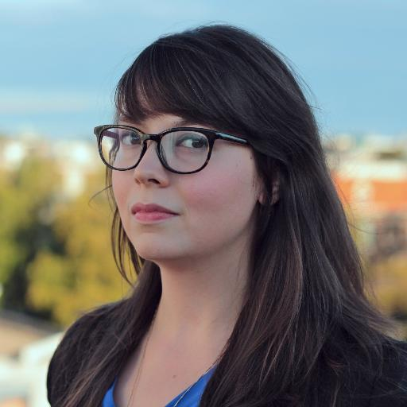

I am **Anca Dumitrache**, a PhD student in the [User-Centric Data Science](http://ucds.cs.vu.nl/) group at [Vrije Universiteit Amsterdam](http://few.vu.nl/).

For the past 4 years I’ve been involved in the [CrowdTruth](http://crowdtruth.org/) project, where we look into how to capture and interpret inter-annotator disagreement in *crowdsourcing*. I am investigating how to use this disagreement to get better training data for *natural language processing* models. My supervisors are [Lora Aroyo](https://loraaroyo.wordpress.com/) and [Chris Welty](https://research.google.com/pubs/104789.html).

Other interests I have include *machine learning*, *Semantic Web*, *open data* and *data science* in general. My programming languages of choice are *R* and *Python* (particularly the scientific Python stack).

In the past, I’ve done internships in the Watson group at [IBM Research](http://research.ibm.com/), and in the NLP department at [Google Research](https://research.google.com/), both in New York. I’ve also been a recipient of the [IBM PhD Fellowship](http://www.research.ibm.com/university/awards/phdfellowship.shtml) from 2014 to 2016.

### Latest News

- Our work on [crowdsourcing medical relation extraction](https://arxiv.org/abs/1701.02185) was mentioned in this [article](https://medium.com/acm-tiis/pay-attention-to-the-man-behind-the-curtain-dc4971419239) about the latest ACM TiiS issue on human-centered machine learning.
- I spent a lovely week at [TMLSS](https://tmlss.ro/) in Cluj-Napoca, Romania, learning about machine & reinforcement learning.
- I presented our paper on frame disambiguation using CrowdTruth at [HCOMP 2018](https://www.humancomputation.com/2018/). **[Paper](https://arxiv.org/abs/1805.00270)** | **[Dataset](https://github.com/CrowdTruth/FrameDisambiguation)** | **[Slides](http://ancad.ro/presentations/HCOMP-2018-slides.pdf)**
- We discussed the new CrowdTruth metrics in the [SAD workshop](https://sadworkshop.wordpress.com/) @ [HCOMP 2018](https://www.humancomputation.com/2018/). **[Paper](http://crowdtruth.org/wp-content/uploads/2018/07/metrics-capturing-ambiguity.pdf)** | **[Code](https://github.com/CrowdTruth/CrowdTruth-core)** | **[Slides](http://ancad.ro/presentations/SAD-2018-slides.pdf)** | **[Poster](http://ancad.ro/presentations/SAD-2018-poster.png)**
- [Figure Eight](https://www.figure-eight.com/) re-published our dataset and task template for [medical relation extraction from sentences](https://www.figure-eight.com/dataset/medical-sentence-summary-and-relation-extraction/) as part of their series of highly curated crowdsourced datasets.

### Planned Travel

- [ISWC 2018](http://iswc2018.semanticweb.org/): October 8-12, Monterey, CA, 🇺🇲
- [EMNLP 2018](http://emnlp2018.org/): October 31 - November 4, Brussels, 🇧🇪

This work is licensed under a [Creative Commons Attribution 4.0 International License](http://creativecommons.org/licenses/by/4.0/).